# Introdução à Econometria

Autor

João Ricardo F. de Lima

Data de Publicação

15 de setembro de 2025

# Revisão de Álgebra Matricial

Diferente da regressão simples, quando se tem apenas uma variável tentando explicar as mudanças em Y, no modelo de regressão múltipla é possível controlar explicitamente muitos outros fatores que, de maneira simultânea, afetam a variável dependente.

Quanto mais variáveis explicativas no modelo, mais variação de Y poderá ser explicada. Assim, a análise de regressão múltipla pode ser usada para construir modelos melhores para prever a variável dependente.

## Definição e tipologia de matrizes

Uma **matriz** é um arranjo retangular de números, denotado por letras maiúsculas em negrito.

Já um **vetor** é um conjunto de números ordenados em uma linha ou coluna, denotado em letras minúsculas, também em negrito.

Tipos comuns de matrizes em econometria:

1. Matrizes simétricas

$$\mathbf{S}=\left[\begin{array}{ccc}
1 & 7 & 8 \\
7 & 2 & 5 \\
8 & 5 & 3 \\
\end{array} \right]$$
II) Matrizes diagonais

$$\mathbf{D}=\left[\begin{array}{ccccc}
3 & 0 & 0 & 0 & 0 \\
0 & 13 & 0 & 0 & 0 \\
0 & 0 & 26 & 0 & 0 \\
0 & 0 & 0 & 14 & 0 \\
0 & 0 & 0 & 0 & 9 \\
\end{array} \right]$$
III) Escalar

$$\mathbf{E}=\left[\begin{array}{c}
3
\end{array} \right]$$
IV) Matriz identidade

$$\mathbf{I}=\left[\begin{array}{ccccc}
1 & 0 & 0 & 0 & 0 \\
0 & 1 & 0 & 0 & 0 \\
0 & 0 & 1 & 0 & 0 \\
0 & 0 & 0 & 1 & 0 \\
0 & 0 & 0 & 0 & 1 \\
\end{array} \right]$$
V) Matriz triangular (superior e inferior)

$$\mathbf{T}=\left[\begin{array}{ccccc}
1 & 3 & 6 & 10 & 20 \\
0 & 31 & 60 & 4 & 18 \\
0 & 0 & 9 & 10 & 110 \\
0 & 0 & 0 & 4 & 77 \\
0 & 0 & 0 & 0 & 3 \\
\end{array} \right]$$

## Manipulação algébrica de matrizes

1. Igualdade: **A=B** $\iff a_{ik}=b_{ik}$;

$$\mathbf{A}=\left[\begin{array}{ccc}
1 & 3 & 6 \\
0 & 31 & 60 \\
0 & 0 & 9 \\
\end{array} \right]=\mathbf{B}=\left[\begin{array}{ccc}
1 & 3 & 6 \\
0 & 31 & 60 \\
0 & 0 & 9 \\
\end{array} \right]$$

2. Transposição: **B=A’** $\iff b_{ik}=a_{ki}$

$$\mathbf{A}=\left[\begin{array}{ccc}
1 & 3 & 6 \\
0 & 31 & 60 \\
0 & 0 & 9 \\
\end{array} \right]$$
$$\mathbf{B}=\mathbf{A'}=\left[\begin{array}{ccc}
1 & 0 & 0 \\
3 & 31 & 0 \\
6 & 60 & 9 \\
\end{array} \right]$$

Se **A** é simétrica, então **A=A’**

$$\mathbf{A}=\left[\begin{array}{ccc}
1 & 3 & 6 \\
3 & 31 & 60 \\
6 & 60 & 9 \\
\end{array} \right]$$

$$\mathbf{A'}=\mathbf{A}=\left[\begin{array}{ccc}
1 & 3 & 6 \\
3 & 31 & 60 \\
6 & 60 & 9 \\
\end{array} \right]$$

3. Adição de matrizes: **C=A+B** $\rightarrow [a_{ik}+b_{ik}]$

$$\left[\begin{array}{ccc}
1 & 3 & 6 \\
0 & 31 & 60 \\
0 & 0 & 9 \\
\end{array} \right]+\left[\begin{array}{ccc}
2 & 4 & 7 \\
1 & 13 & 0 \\
4 & 20 & 19 \\
\end{array} \right]=\mathbf{C}\left[\begin{array}{ccc}
3 & 7 & 13 \\
1 & 44 & 60 \\
4 & 20 & 28 \\
\end{array} \right]$$

4. Matrizes são multiplicadas usando o **produto interno** o qual, para dois vetores **a** e **b** é dado por:

$${a'b}=a_1b_1+a_2b_2+\ldots+a_nb_n$$

Assim, para uma matriz **A** de ordem $n\times K$ e uma matriz **B** de ordem $K \times M$, a matriz produto **C** é uma matriz $n \times M$:

$$C=AB\rightarrow c_{ik}=\mathbf{a_i'b_k}$$

### Exemplo de multiplicação com matrizes quadradas

$$\left[\begin{array}{cc}
1 & 3 \\
0 & 31 \\
\end{array} \right]x\left[\begin{array}{cc}
2 & 4 \\
1 & 13 \\
\end{array} \right]=\mathbf{C}=\left[\begin{array}{cc}
(1x2)+(3x1) & (1x4)+(3x13) \\
(0x2)+(31x1) & (0x4)+(31x13)\\
\end{array} \right]$$
$$\mathbf{C}=\left[\begin{array}{cc}
5 & 43 \\
31 & 403\\
\end{array} \right]$$

### Exemplo de multiplicação com matrizes com dimensões diferentes

$$\mathbf{A=}\left[\begin{array}{cc}
1 & 3 \\
0 & 31 \\
15 & 4 \\
\end{array} \right]x\mathbf{B}=\left[\begin{array}{cc}
2 & 4 \\
1 & 13 \\
\end{array} \right]=\mathbf{C}=\left[\begin{array}{ccc}
(1x2)+(3x1) & (1x4)+(3x13) \\
(0x2)+(31x1)& (0x4)+(31x13) \\
(15x2)+(4x1) & (15x4)+(4x13)\\
\end{array} \right]$$

$$\mathbf{C}=\left[\begin{array}{ccc}
5 & 43 \\
31& 403 \\
34 & 112 \\
\end{array} \right]$$
A matriz A possui dimensão 3x2 e a matriz B possui dimensão 2x2. Como o número de colunas da matriz A é igual ao número de linhas da matriz B, a multiplicação pode ser feita. O resultado será uma matriz C com dimensão 3x2.

Não seria possível multiplicar a matriz B pela matriz A, pois o número de colunas da matriz B não é igual ao número de linhas da matriz A.

## Soma de Valores

Seja **i** um vetor coluna de $1's$ e **x** um vetor coluna qualquer. Então:

$$\sum\limits_{i=1}^{n}x_i=x_1+x_2+\ldots+x_n=\mathbf{i'x}$$

$$\mathbf{x}=\left[\begin{array}{c}
5 \\
31 \\
34 \\
\end{array} \right]$$

$$\mathbf{i}=\left[\begin{array}{c}
1 \\
1 \\
1 \\
\end{array} \right]$$
$$\mathbf{i'}=\left[\begin{array}{ccc}
1 & 1 & 1 \\
\end{array} \right] x \mathbf{x}=\left[\begin{array}{c}
5 \\
31 \\
34 \\
\end{array} \right]=\sum\limits_{i=1}^{n}x_i=70$$
É possível multiplicar pois a matriz $i'$ tem dimensão 1x3 e a matriz x tem dimensão 3x1. O número de colunas da matriz $i'$ é igual ao número de linhas da matriz x. A matriz resultante possui o número de linhas de $i'$ e o número de colunas de x, ou seja, vai ser 1x1.

Se todos os elementos em **x** são iguais a uma constante *a*, então

$\mathbf{x}=a\mathbf{i}$ e

$$\sum\limits_{i=1}^{n}x_i=\mathbf{i'}(a\mathbf{i})=a(\mathbf{i'i})=na$$

Se $a=1/n$, então obtem-se a média aritmética de *x*:

$$\bar{x}=\frac{1}{n}\sum\limits_{i=1}^{n}x_i=\frac{1}{n}\mathbf{i'x}$$
Logo, tem-se um resultado útil para derivações futuras no curso:

$$\sum\limits_{i=1}^{n}x_i=\mathbf{i'x}=n\bar{x}$$

## Soma de valores ao quadrado

A soma dos quadrados dos elementos de **x**, e de **x** por **y** é:

$$\sum\limits_{i=1}^{n}x_i^2=\mathbf{x'x}\qquad \sum\limits_{i=1}^{n} x_iy_i=\mathbf{x'y}$$

E, pela definição de multiplicação de matrizes:

$$[\mathbf{X'X}]_{kl}=[\mathbf{x_k'x_l}]$$

é o produto interno da $k-$ésima e $l-$ésima colunas de **X**.

## (In)dependência linear e posto de uma matriz

Um conjunto de vetores é **linearmente dependente** se qualquer um dos vetores no conjunto pode ser expresso como uma combinação linear dos demais.

Um conjunto de vetores é **linearmente independente** se e somente se a única solução para $\alpha_1\mathbf{a_1}+\alpha_2\mathbf{a_2}+\ldots+\alpha_k\mathbf{a_k}=0$ é $\alpha_1=\alpha_2=\ldots=\alpha_k=0$.

O **posto** (ou, do inglês, **rank**) de uma matriz equivale ao número de linhas (ou colunas) linearmente independentes.

De modo equivalente, o posto de uma matriz **A** $p \times q$ é igual ao valor $r$ para o qual existe uma submatriz de **A** de tamanho $r \times r$ que possui determinante não nulo.

## Determinante de uma matriz

O **determinante** de uma matriz quadrada é uma função dos elementos da matriz. Def.: O **determinante** de uma matriz é não-nulo se e somente se a mesma possui posto cheio.

Para uma matriz diagonal **D**:

$$\mathbf{D}=\left[\begin{array}{ccccc}
d_1 & 0 & 0 & \ldots & 0 \\
0 & d_2 & 0 & \ldots & 0 \\
& & & \ddots & \\
0 & 0 & 0 & \ldots & d_K
\end{array} \right]$$
O determinante é dado pelo produtório dos termos da diagonal principal:

$$|\mathbf{D}|=\prod\limits_{k=1}^{K}d_k$$

Para uma matriz $2 \times 2$, o cálculo do determinante é dado por:

$$\begin{array}{|cc|}
a & c \\
b & d
\end{array} =ad-bc$$

Observe que o determinante é uma função de todos os elementos da matriz.

Para matrizes com dimensões superiores a 2, utilizamos a expansão por cofatores:

$$|\mathbf{A}|=\sum\limits_{k=1}^{K}a_{ik}(-1)^{i+k}|\mathbf{A}_{ik}|,\qquad k=1,\ldots,K.$$

## Menor e Cofator

Se a i-ésima linha e a j-ésima coluna de uma matriz A de origem N x N são excluídas, o determinante da submatriz resultante é chamado de o **menor** do elemento $a_{ij}$ (o elemento na interseção da i-ésima linha e a j-ésima coluna) e é denotado por $|M_{ij}|$.

O cofator do elemento $a_{ij}$ de uma matriz A de origem N x N, denotado por $c_{ij}$, é definido como

$$c_{ij}=(-1)^{i+j}|M_{ij}|$$

um cofator é um menor sinalizado, com sinal positivo se i + j for par e negativo se i + j for ímpar.

Substituindo os elementos $a_{ij}$ de uma matriz A pelos seus cofatores, se obtém uma matriz conhecida como **matriz de cofator** de A, denotada por (cof A).

A **matriz adjunta**, escrita como (adj A), é a transposta da matriz de cofator; $(adj$ $A) = (cof$ $A)'$.

## Matrizes Inversas

Uma matriz quadrada **A** $p \times p$ possui inversa se existe uma matriz **B** $p \times p$ tal que $\mathbf{AB=BA=I}$;

Tal matriz **B** é denominada **inversa** de **A** e denotada $\mathbf{A^{-1}}$, com as seguintes propriedades:

$$(\mathbf{AB})^{-1}=\mathbf{B^{-1}A^{-1}}; \quad \mathbf{A^{-1}A}=\mathbf{AA^{-1}=I}$$

$$(\mathbf{A'})^{-1}=(\mathbf{A}^{-1})'; \quad (\mathbf{A}^{-1})^{-1}=\mathbf{A}$$
Se A é quadrada e não singular ($|A| \neq 0$), a sua inversa $A^-1$ pode ser encontrada da seguinte forma:

$$\mathbf{A}^{-1}=\frac{1}{\mathbf{|A|}}(adj \quad \mathbf{A})$$

Os passos envolvidos no cálculo são os seguintes:

1. Descubra o determinante de A. Se não for zero, execute o passo 2.
2. Substitua cada elemento ai j de A por seu cofator para obter a matriz de cofator.
3. Transponha a matriz de cofator para obter a matriz adjunta.
4. Divida cada elemento da matriz adjunta por |A|.

**Matrizes singulares** são matrizes que não possuem inversa.

## Matrizes particionadas

Em algumas situações é útil agrupar os elementos de uma matriz em **submatrizes**. Seja:

$$\mathbf{A}=\left[\begin{array}{cc|c}
1 & 4 & 5 \\
2 & 9 & 3 \\
\hline
8 & 9 & 6
\end{array} \right]=\left[\begin{array}{cc}
\mathbf{A_{11}} & \mathbf{A_{12}} \\
\mathbf{A_{21}} & \mathbf{A_{22}}
\end{array} \right]$$
Um caso especial é a matriz bloco-diagonal:

$$\mathbf{A}=\left[\begin{array}{cc}
\mathbf{A_{11}} & 0 \\
0 & \mathbf{A_{22}}
\end{array} \right]$$

# Modelo de Regressão Múltipla

## Estimação dos betas por MQO

Será apresentado o Modelo Clássico de Regressão Linear envolvendo k variáveis, com $k>2$ $(Y, X_1, X_2, X_3, ..., X_k)$.

Apresentado na forma matricial em (1)

$$\mathbf{Y}=\left(\begin{array}{c}
y_1\\
\vdots\\
y_n
\end{array}\right), \mathbf{ X}=\left(\begin{array}{cccc}
1 & x_{12} & \ldots & x_{1k}\\
\vdots& \vdots & \ddots & \vdots \\
1 & x_{n2} & \ldots & x_{nk}\\
\end{array}\right), \boldsymbol{\hat \beta}=\left(\begin{array}{c}
\beta_1\\
\vdots\\
\beta_k
\end{array}\right), \boldsymbol{\hat u}=\left(\begin{array}{c}
u_1\\
\vdots\\
u_n
\end{array}\right)
\tag{1}$$

Na notação matricial, reescreve-se (1) como:

$$Y=X\hat \beta+\hat u
\tag{2}$$

O modelo de regressão com $k>2$ variáveis é conhecido como **modelo de regressão múltipla**. O **modelo de regressão múltipla** é uma extensão do modelo de regressão simples. Contudo, as fórmulas matemáticas usadas para calcular $\hat \beta_1$ e $\hat \beta_2$ no modelo simples nao podem ser usadas no modelo múltiplo.

Uma forma fácil de se trabalhar com modelos de regressão múltipla é usando algebra matricial. A maior vantagem é que a solução para se estimar os coeficientes pode ser usado para simples e múltipla com qualquer número de variáveis explicativas.

Para se obter a solução do estimador de $\beta$ na forma matricial, inicialmente se escreve a função de regressão com k-variáveis:

$$Y_i=\hat \beta_1+ \hat \beta_2 X_{2i}+\hat \beta_3 X_{3i}+ \dots+\hat \beta_k X_{ki}+ \hat u_i$$

que pode ser escrito na forma matricial: com Y sendo um vetor coluna nx1; X uma matriz nxk; $\hat \beta$ um vetor coluna kx1 e o termo estocástico um vetor coluna nx1.

Os estimadores de MQO são obtidos pela minimização de:

$$\sum \hat u_i^2= \sum(Y_i- \hat \beta_1 - \hat \beta_2 X_{2i}- \dots -\hat \beta_k X_{ki})^2
\tag{3}$$

com $\sum \hat u_i^2$ sendo a soma de quadrados dos resíduos. Matricialmente, a soma do quadrados dos resíduos é dada por $\hat u' \hat u$. A partir de (2), obtem-se

$$\hat u=Y - X\hat \beta$$

Assim:

$$\sum \hat u_i^2 = \hat u'\hat u=(Y-X\hat \beta)'(Y-X\hat \beta)$$

$$=Y'Y-Y'X\hat \beta-\hat \beta' X'Y+ \hat \beta' X'X \hat \beta$$

dado que $Y'X\hat \beta$ é um escalar, é igual a sua transposta $\hat \beta'X'Y$. O último termo é a forma quadrática dos elementos de $\beta$. Então,

$$\hat u'\hat u=Y'Y-2\hat \beta'X'Y+\hat \beta' X'X \hat \beta$$

que é a função que desejamos minimizar. Para encontrar o ponto de ótimo, deve-se derivar a função e igualá-la a zero.

$$\frac {\partial \hat u'\hat u}{\partial \hat \beta}=-2X'Y+2X'X\hat \beta=0
\tag{4}$$

$$X'X\hat \beta=X'Y
\tag{5}$$

multiplicando os 2 lados por $(X'X)^{-1}$

$$(X'X)^{-1}X'X\hat \beta=(X'X)^{-1}X'Y
\tag{6}$$

tem-se

$$\hat \beta=(X'X)^{-1}X'Y
\tag{7}$$

## Demonstração no R

```r
library(wooldridge)
# Carrega a base 'wage2'
data(wage2)
# Remove os valores ausentes (NAs)
sal <- na.omit(wage2)

# Dimensão da base (# linhas  # colunas)
dim(sal)
```

```
[1] 663  17
```

```r
# Descrição da base
str(sal)
```

```
'data.frame':   663 obs. of  17 variables:
 $ wage   : int  769 825 650 562 600 1154 1000 930 1318 1792 ...
 $ hours  : int  40 40 40 40 40 45 40 43 38 40 ...
 $ IQ     : int  93 108 96 74 91 111 95 132 119 118 ...
 $ KWW    : int  35 46 32 27 24 37 44 44 24 47 ...
 $ educ   : int  12 14 12 11 10 15 12 18 16 16 ...
 $ exper  : int  11 11 13 14 13 13 16 8 7 9 ...
 $ tenure : int  2 9 7 5 0 1 16 13 2 9 ...
 $ age    : int  31 33 32 34 30 36 36 38 28 34 ...
 $ married: int  1 1 1 1 0 1 1 1 1 1 ...
 $ black  : int  0 0 0 0 0 0 0 0 0 0 ...
 $ south  : int  0 0 0 0 0 0 0 0 0 0 ...
 $ urban  : int  1 1 1 1 1 0 1 0 1 1 ...
 $ sibs   : int  1 1 4 10 1 2 1 1 3 1 ...
 $ brthord: int  2 2 3 6 2 3 1 1 1 1 ...
 $ meduc  : int  8 14 12 6 8 14 12 13 10 12 ...
 $ feduc  : int  8 14 12 11 8 5 11 14 10 12 ...
 $ lwage  : num  6.65 6.72 6.48 6.33 6.4 ...
 - attr(*, "time.stamp")= chr "25 Jun 2011 23:03"
 - attr(*, "na.action")= 'omit' Named int [1:272] 2 6 8 12 13 19 20 21 31 36 ...
  ..- attr(*, "names")= chr [1:272] "2" "6" "8" "12" ...
```

O Modelo proposto para ser estimado é:

$$log(wage)= \beta_0 +\beta_1 educ + \beta_2 exper + \beta_3exper^2+ \beta_4 tenure + u$$
onde:

lwage = o logaritmo natural do salário

educ = anos de educação

exper = anos de experiência (trabalhando)

tenure = anos trabalhando com o empregador atual

```r
# Define alguns valores úteis:
## N = número de observações
## k = número de betas estimados
## const = vetor com 1's (uns)

N <- 663
k <- 5
const <- rep(1, 663)

# Monta a matriz de observações da regressão
X <- cbind(const, sal$educ, sal$exper, sal$exper^2, sal$tenure)
X <- as.matrix(X)

# Define o nome das colunas da matriz de observações
colnames(X) <- c("const", "educ", "exper", "exper2", "tenure")

# Função para verificar as primeiras linhas da matriz X
head(X)
```

```
     const educ exper exper2 tenure
[1,]     1   12    11    121      2
[2,]     1   14    11    121      9
[3,]     1   12    13    169      7
[4,]     1   11    14    196      5
[5,]     1   10    13    169      0
[6,]     1   15    13    169      1
```

```r
# Função para verificar as últimas linhas da matriz X
tail(X)
```

```
       const educ exper exper2 tenure
[658,]     1   12     9     81      2
[659,]     1   16     8     64     10
[660,]     1   12    11    121      3
[661,]     1   12     9     81      3
[662,]     1   16    10    100      9
[663,]     1   13    10    100      3
```

```r
# Define o vetor y (log do salário)
y <- sal$lwage

# O operador de multiplicação matricial é ``%*%``.

# Computa a estimativa para os betas
(beta <- solve(t(X) %*% X) %*% t(X) %*% y)
```

```
               [,1]
const  5.5430835393
educ   0.0763885961
exper  0.0079634323
exper2 0.0004488306
tenure 0.0095632078
```

## Matriz de Variância/Covariância dos $\beta$’s

Por definição, a matriz de variância/covariância dos $\beta$’s é dada por:

$$\mathbf{var-cov(\hat \beta)}=E{[\hat \beta- \beta][\hat \beta -\beta]'}$$

$$\mathbf{var-cov(\hat \beta)}=E[\mathbf{(X'X)^{-1}X'\boldsymbol{uu}'X(X'X)^{-1}]}$$

$$\mathbf{var-cov(\hat \beta)}=\mathbf{(X'X)^{-1}X}'E[\boldsymbol{uu}']\mathbf{X(X'X)^{-1}}$$

$$\mathbf{var-cov(\hat \beta)}=\mathbf{(X'X)^{-1}X}'\sigma^2\mathbf{X(X'X)^{-1}}$$

$$\mathbf{var-cov(\hat \beta)}=\sigma^2\mathbf{(X'X)^{-1}X'X(X'X)^{-1}}=\sigma^2(\mathbf{X'X})^{-1}$$

$$\mathbf{var-cov(\hat \beta)}=\left[\begin{array}{cccc}
var(\hat \beta_1) & cov(\hat \beta_1, \hat \beta_2) & \ldots & cov(\hat \beta_1, \hat \beta_k) \\
cov(\hat \beta_2, \hat \beta_1) & var(\hat \beta_2) & \ldots & cov(\hat \beta_2, \hat \beta_k) \\
\vdots &\vdots &\ddots &\vdots \\
cov(\hat \beta_k, \hat \beta_1) & cov(\hat \beta_k, \hat \beta_2) & \ldots & var(\hat \beta_k) \\
\end{array} \right]$$

Os elementos da diagonal desta matriz são as variâncias dos estimadores dos parâmetros individuais, e os elementos fora da diagonal são as covariâncias entre estes estimadores.

como $\mathbf{\hat \sigma^2}$ é desconhecido, usa-se sua estimativa:

$$\mathbf{\hat \sigma^2}=\frac{SQR}{n-k}=\mathbf{\frac{y'y-\hat \beta'X'y}{n-k}}
\tag{8}$$

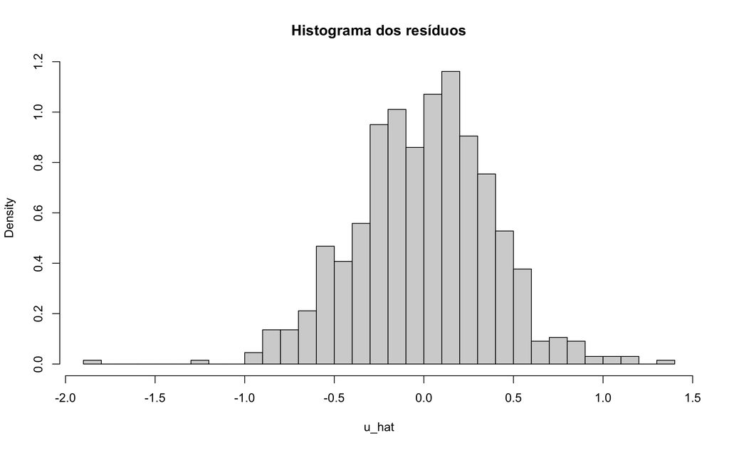

```r
# Computa o resíduo da regressão
u_hat <- y - X %*% beta

# Histograma dos resíduos
hist(u_hat, breaks = 30, freq = FALSE, main = "Histograma dos resíduos")
```

```r
# Computa a variância
(sigma <- t(u_hat) %*% u_hat / (N - k))
```

```
          [,1]
[1,] 0.1437451
```

```r
# Computa o desvio-padrão
(dp <- sqrt(sigma))
```

```
          [,1]
[1,] 0.3791373
```

```r
# Computa a variância dos coeficientes
(var_cov <- solve(t(X) %*% X) * as.numeric(sigma))
```

```
               const          educ         exper        exper2        tenure
const   2.015144e-02 -8.391442e-04 -1.259396e-03  4.053681e-05 -1.400612e-05
educ   -8.391442e-04  5.650348e-05 -8.720532e-07  6.672702e-07 -3.138122e-06
exper  -1.259396e-03 -8.720532e-07  2.390352e-04 -9.952987e-06  2.780852e-06
exper2  4.053681e-05  6.672702e-07 -9.952987e-06  4.454019e-07 -2.978516e-07
tenure -1.400612e-05 -3.138122e-06  2.780852e-06 -2.978516e-07  9.605291e-06
```

```r
# Computa o desvio padrão dos coeficientes
(ep_coef <- sqrt(diag(var_cov)))
```

```
       const         educ        exper       exper2       tenure
0.1419557709 0.0075168794 0.0154607620 0.0006673844 0.0030992404
```

```r
# Teste t para significancia dos betas
(t_test <- beta / ep_coef)
```

```
             [,1]
const  39.0479619
educ   10.1622750
exper   0.5150737
exper2  0.6725219
tenure  3.0856618
```

## Viés de Estimadores dos $\beta$’s

Pode-se demonstrar que o $\beta$ estimado por MQO não é viesado da seguinte forma:

$$\hat \beta=(X'X)^{-1}X'Y$$

$$\hat \beta=(X'X)^{-1}X'(X\beta + u)$$

$$\hat \beta=(X'X)^{-1}X'X\beta + (X'X)^{-1}X'u$$

$$\hat \beta=I\beta + (X'X)^{-1}X'u$$

$$E(\hat \beta|X)=\beta +E[(X'X)^{-1}X'u|X]$$

$$E(\hat \beta|X)=\beta$$

```r
t(X) %*% u_hat
```

```
                [,1]
const  -6.377388e-11
educ   -6.765211e-10
exper  -7.966054e-10
exper2 -1.130498e-08
tenure -4.340164e-10
```

Por definição, o $R^2$ por via matricial é calculado por:

$$\mathbf{R^2=\frac{\hat \beta' X'y-n\bar{Y}^2}{y'y-n\bar Y^2}}
\tag{9}$$

```r
l <- rep(1, N)
y_til <- y - l %*% solve(t(l) %*% l) %*% t(l) %*% y
(r2 <- 1 - t(u_hat) %*% u_hat / t(y_til) %*% y_til)
```

```
          [,1]
[1,] 0.1591249
```

Por definição, o $F$ por via matricial é:

$$\mathbf{F=\frac{(\hat \beta' X'y-n\bar{Y}^2)/(k-1)}{(y'y-\hat \beta' X'y)/(n-k)}}
\tag{10}$$

Contudo, pode-se testar uma hipótese conjunta como $\beta_2=\beta_3=0$ usando o teste F. Para fazer isto, estima-se um modelo restrito e compara-se a soma dos quadrados dos resíduso deste modelo contra o original. Definindo a soma do quadrado dos resíduos do modelo restrito como SSRR e do irrestrito como SSRI tais que:

$$SSR_R= \sum\limits_{i=1}^{N}(y_i-x_i'\hat \beta_{res})$$
$$SSR_I= \sum\limits_{i=1}^{N}(y_i-x_i'\hat \beta_{irres})$$
Monta-se a estatística F segundo a expressão abaixo:

$$\frac{\frac{SSR_R-SSR_I}{q}}{\frac{SSR_I}{N-k-1}}$$
O Modelo irrestrito é o original estimado. O modelo restrito faz $\beta_2=\beta_3=0$.

```r
# Monta a matriz de observações da estimação restrita
X_res <- cbind(const, sal$educ, sal$tenure)
X_res <- as.matrix(X_res)
colnames(X_res) <- c("const", "educ", "tenure")
# Estima os betas da regressão restrita
beta_res <- solve(t(X_res) %*% X_res) %*% t(X_res) %*% y
# Computa o resíduo da regressão restrita
u_res <- y - X_res %*% beta_res
# Computa a soma do quadrado dos resíduos (reg. restrita)
(ssr_res <- sum(u_res^2))
```

```
[1] 97.44856
```

```r
# Computa a soma do quadrado dos resíduos (reg. irrestrita)
(ssr_irres <- sum(u_hat^2))
```

```
[1] 94.58429
```

```r
# Computa o teste F
(teste_f <- ((ssr_res - ssr_irres) / 2) / (ssr_irres / (N - k - 1)) )
```

```
[1] 9.947883
```

```r
# Computa o valor crítico (95%) do teste F
(f95 <- qf(0.95, 2, N - k - 1))
```

```
[1] 3.009434
```

```r
# Computa o p-valor associado ao teste F acima
(pvalor <- 1 - pf(teste_f, 2, N - k - 1))
```

```
[1] 5.543874e-05
```